WEEK 5 Logistic Regression Sarah Sachs

[figure not shown]

### Part I

# Yes/no outcomes

## In this lecture…

### Move from predicting a number to predicting the probability of a yes/no outcome.

See why linear regression is the wrong tool for a probability. Odds, log-odds, the logistic curve and maximum likelihood. Turn a predicted probability into a decision, and judge it with a confusion matrix. Extend to several predictors, and to outcomes with more than two categories. The limits: extrapolation, separation and uncertainty.

Same example data as last week: deliveries, distance. Different question:

Was the delivery “late” or “on time”?

## From a number to a yes/no

### Last week: linear regression

𝑌 = 𝑏0 + 𝑏1𝑋

𝑌 was a number: minutes.

The line predicted a value. Least squares to compute 𝑏0, 𝑏1.

### This week: logistic regression

𝑝 = something(𝑏0 + 𝑏1𝑋) 𝑌 is a label: “late” or “on time”. The model predicts a probability. Maximum likelihood to compute

𝑏0, 𝑏1.

Everything else carries over: a predictor, coefficients to interpret, a fit to judge, and the question of whether it works on new deliveries.

## Motivation

Plenty of outcomes are not numbers but labels:

Will this delivery be late? Is this email spam? Will this patient respond to treatment? Will this customer renew?

Each has the same three ingredients as before: an outcome we care about, information that may predict it, and previous observations to learn from.

Recurring example: our courier promises delivery within 30 minutes. Given the distance, what is the chance the promise is broken?

## The same deliveries, a new question

50

40

20

[figure not shown]

30 promise: 30 minutes

10

0

5

10

Distance (km)

15

Late (15 deliveries) above the line, on time (22) below it.

20

## The data, recoded

We now record, for each delivery,

𝑌 = {1 0

late on time

Distance Time 𝑌

2 9 11 13 17

13 0 22 0 27 0 34 1 40 1

⋮

1

0.5

0

0

5

10

Distance (km)

15

20

All the points sit on two lines, 0 and 1. Deliveries with short distances tend to be on the bottom

row, long ones on the top.

We want to predict the probability that a delivery is late.

## Why not just fit a straight line?

Least squares still runs. It gives

𝑌 = −0.37 + 0.075𝑋.

At 1 km it predicts −0.30. At 20 km it predicts 1.13.

1

0.5

0

0 20 𝑝 < 0? 𝑝 > 1? 5 15 10

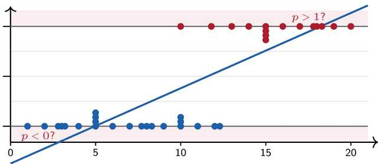

Distance (km)

Predict that at 1 km, a delivery will be late with probability −0.3?

No! Probabilities have to be between 0 and 1.

## Quick check: Part I

Why can we not model the probability of being late with a straight line in 𝑋?

A A line eventually leaves the interval [0, 1], and a probability cannot

C Because 𝑌 takes only two values, the slope is always zero

B Least squares cannot be computed for a 0/1 outcome

D We can, there is nothing wrong with it

## From probability to odds and log-odds

0

−∞

0.5

1

2.5 2 Probability 𝑝 Odds 1 − 𝑝 𝑝 1.5 0 1 0.5

[figure not shown]

−1

### Log-odds log 1 − 𝑝 𝑝

0

∞

+∞

1

2

Logistic regression puts the straight line on the log-odds, which can take any value:

log 1 − 𝑝 𝑝 = 𝑏0 + 𝑏1𝑋 .

Solving this for 𝑝 then always gives a probability in [0, 1].

## The logistic curve

Solving for 𝑝:

log 1 − 𝑝 𝑝 = 𝑏0 + 𝑏1𝑋 ,

gives the logistic function

1

𝑝 = 1 + 𝑒−(𝑏0+𝑏1𝑋) .

It can never leave [0, 1]. It is flat where the answer is nearly certain. It is steepest where the answer is a coin flip.

1

0.5

0 0

5

10

Distance (km)

15

20

Fitted to our 37 deliveries: log 1−𝑝 𝑝 = −13.2 + 1.1𝑋.

## The logistic model, piece by piece

log 1 − 𝑝 𝑝 = 𝑏0 + 𝑏1𝑋

1

0.5

0

becomes 𝑝 =

1

1 + 𝑒−(−13.2+1.1𝑋)

𝑝 = 0.10 at 𝑋 = 10 steepest here

[figure not shown]

0

5

10 12

Distance (km)

15

20

## Reading the slope: odds ratios

For our model 𝑏1 = 1.1.

𝑒𝑏1 = 𝑒1.1 ≈ 3.0.

Each extra kilometre multiplies the odds of being late by about 3.

The probabilities do not multiply by 3.

km log-odds

odds 𝑝

−2.2 1/9 0.10 10 −2.2

11 −1.1 12

13 14

1/3 0.25

0.0 1 0.50 1.1 3 0.75 2.2 9 0.90

The odds column triples every row. The probability column does not: it climbs 15 points, then 25, then 25, then 15.

## Making a prediction

A new delivery is 10 km away.

log 1 − 𝑝 𝑝 = −13.2 + 1.1(10) = −2.2

1

𝑝 = 1 + 𝑒2.2 = 0.10.

About a 10% chance of be ing late.

At 12 km it is a coin flip; at 14 km, 90%.

1 0.90

0.5 0.50

0

0.10

[figure not shown]

0

5

10

Distance (km)

15

Four kilometres take us from a 10% to a 90% chance of being late.

20

## Quick check: Part II

Our model has 𝑏1 = 1.1, so 𝑒1.1 ≈ 3. What does that mean?

A Each extra kilometre adds 3 percentage points to the probability of being late

C Each extra kilometre multiplies the odds of being late by about 3

B A delivery is three times more likely to be late than on time

D The probability of being late is 3𝑋

### Part III

# Maximum likelihood

## The likelihood of what we actually saw

Any candidate curve assigns a probability to each delivery’s actual outcome:

{ 𝑝𝑖 1 − 𝑝𝑖

if it was late (𝑌𝑖 = 1), if it was on time (𝑌𝑖 = 0).

Multiply them together:

𝐿 = ∏𝑛 𝑝 𝑖 𝑌𝑖 (1 − 𝑝𝑖)1−𝑌𝑖 .

𝑖=1

1

0.5

0 0

5

10

15

steep flat

delivery 5 km, on time 10 km, on time 12 km, late 14 km, late 18 km, late product

1.00 0.91 0.90 0.62 0.50 0.55 0.90 0.71 1.00 0.91

0.40 0.20

20

## Where do the 𝑋𝑖 come in?

Read the curve at each delivery’s own 𝑋𝑖:

1

𝑝𝑖 = 1 + 𝑒−(𝑏0+𝑏1𝑋𝑖) ,

1

1 − 𝑝𝑖 = 1 + 𝑒 𝑏0+𝑏1𝑋𝑖 .

𝑋𝑖 says where to read the curve; 𝑌𝑖 says which probability counts; both are data — only 𝑏0, 𝑏1 are free. Substituting into 𝐿 puts every 𝑋𝑖 in view:

1

0.5 0

1.00 late: bar = on time: bar 1.00 ?̂?𝑖 = 1 − ?̂?𝑖 0.90 0.50 0.90

[figure not shown]

0

5

10

Distance 𝑋𝑖 (km)

15

The fitted curve, read at each 𝑋𝑖. Its bars multiply

to 1.00 × 0.90 × 0.50 × 0.90 × 1.00 = 0.40.

Change 𝑏0 or 𝑏1 and every bar changes at once.

𝐿(𝑏0, 𝑏1) = ∏𝑛 ( 1 + 𝑒−(𝑏0+𝑏1𝑋𝑖) 1 )𝑌𝑖( 1 + 𝑒 𝑏0+𝑏1𝑋𝑖 1 )1−𝑌𝑖 .

𝑖=1

20

## Maximum likelihood

Maximum likelihood picks the 𝑏0, 𝑏1 that make the observed pattern of lates and on-times as probable as possible.

### The parallel with last week

Least squares:

min𝑏0,𝑏1 ∑(𝑌𝑖 − (𝑏0 + 𝑏1𝑋𝑖))2

#### Maximum likelihood

max𝑏0,𝑏1 𝐿(𝑏0, 𝑏1)

- 6
- 7
- 8
- 9
- 10
- 11

best: 𝑏1 = 1.1

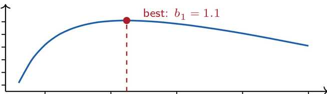

0.5

1.0

1.5

2.0

2.5

𝑏1

Each 𝑏1 is scored by how probable it makes our 37 deliveries (with 𝑏0 set to its best value each time). The peak is the estimate.

## Quick check: Part III

A candidate curve gives a delivery that was late a probability of 0.02. What does that do to the likelihood ∏𝑛 𝑖=1 𝑝 𝑖 𝑌𝑖 (1 − 𝑝𝑖)1−𝑌𝑖?

A Nothing — likelihood only counts how many predictions were on the right side

C It adds 0.02 to the total

B It multiplies the likelihood by 0.98 D It multiplies the likelihood by 0.02, so that curve is heavily penalised

### Part IV

# Model quality

## From a probability to a decision

The model returns 0.10, 0.50, 0.90 — but the dispatcher has to do something: warn the customer, or not. Pick a threshold. With the obvious choice 0.5:

predict “late” when 𝑝 ≥ 0.5

which for our model means simply

predict “late” when the dis tance is 12 km or more.

1

0.5

0

predict “late” predict “on time”

[figure not shown]

0

5

10

Distance (km)

15

20

A threshold turns a curve into a cut-off distance.

## The confusion matrix

predicted late

was late

was on time

predicted on time

| 13 | 2 |
| --- | --- |
| 2 | 20 |

threshold 0.5, all 37 deliveries

13 late deliveries correctly flagged; 20 on-time deliveries correctly left alone; 2 false alarms (warned, arrived on time); 2 misses (not warned, arrived late).

13 + 20

accuracy =

37 = 0.89.

The two kinds of error are not the same thing, and rarely cost the same.

## Accuracy: compared with what?

Our model is right 89% of the time. Is that good? The lazy baseline: ignore distance and always say on time. It is right for 22 of 37 deliveries. baseline accuracy = 37 22 = 0.59. So distance takes us from 59% to 89%.

predicted late

was late

was on time

predicted on time

| 0 | 15 |
| --- | --- |
| 0 | 22 |

always predict “on time”: accuracy 0.59

predicted late

was late

was on time

predicted on time

13 2 2 20

[figure not shown]

our model: accuracy 0.89

Careful: if only 3% of deliveries were ever late, the lazy baseline would score 97% — and be useless. Accuracy alone never settles the question.

## Moving the threshold

threshold 0.1

warn beyond 10 km

pred. late

late

on time

pred. o.t.

| 14 | 1 |
| --- | --- |
| 3 | 19 |

catches 14 of 15 3 false alarms

threshold 0.5

warn from 12 km

pred. late

late

on time

pred. o.t.

2 20 13 2

catches 13 of 15 2 false alarms

threshold 0.7

warn beyond 12.8 km

pred. late

late

on time

pred. o.t.

| 13 | 2 |
| --- | --- |
| 0 | 22 |

catches 13 of 15 no false alarms

Same model, same coefficients, only the cut-off moved. Lowering it catches more late deliveries at the cost of crying wolf; raising it does the reverse. Where to put it is a business decision about the relative cost of the two errors.

## Quick check: Part IV

The courier lowers the warning threshold from 0.5 to 0.1. What happens?

A The model becomes more accurate by definition

C The fitted coefficients 𝑏0 and 𝑏1 change

B More late deliveries are caught, but there are more false alarms

D Nothing — the threshold only affects the probabilities

### Part V

# Generalisation

## Training and test deliveries

Same split as last week: 29 deliveries to fit, 8 held back.

The curve is estimated from the solid points only; the rings are then classified at threshold 0.5.

accuracy

Training deliveries Held-out deliveries

27/29 = 0.93 7/8 = 0.88

1

0.5

0

0

5

10

Distance (km)

15

20

Rings: the held-out deliveries. One of the eight is misclassified.

1

0.5

0

## Underfitting and overfitting

Underfitting

0

5

10

15

ignores distance: ?̂? = 0.41 always

Useful fit

1

0.5

0

[figure not shown]

20

Overfitting

0

5

10

15

a graded probability

20

1

0.5

0

0

5

10

15

fitted to 20 deliveries: a cliff

The right-hand curve was fitted to a subsample and came out almost vertical: it claims to know that 11.9 km is safe and 12.1 km is doomed. It fits those 20 deliveries better than the middle curve and will do worse on the next one.

The logistic version of overfitting is over-confidence: probabilities pushed to 0 and 1 that the data cannot support.

20

## Quick check: Part V

A fitted logistic model returns probabilities of 0.001 and 0.999 and almost nothing in between, and classifies its training deliveries perfectly. What should you suspect?

A Overfitting — the curve has been pushed into a near-vertical step

C The threshold is set wrongly

### B An excellent model

D The outcome must have been mislabelled

### Part VI

# More than one predictor

## What if one predictor is not enough?

The company also recorded the weather. Adding it:

log 1 − 𝑝 𝑝 = 𝑏0 + 𝑏1𝑋1 + 𝑏2𝑋2

with 𝑋1 the distance and 𝑋2 = 1 if it was raining (0 otherwise).

Fitted to our 37 deliveries:

−14.4 + 1.2 Distance + 1.4 Rain.

1

0.5

0

dry rain

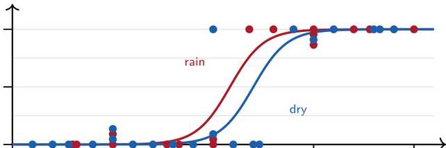

0

5

10

Distance (km)

15

Colour indicates the weather.

20

## Interpreting the coefficients

log 1 − 𝑝 𝑝 = −14.4 + 1.2 (Distance) + 1.4 (Rain)

𝑒1.2 ≈ 3.3: holding the weather fixed, each extra kilometre multiplies the odds of being late by about 3.3.

𝑒1.4 ≈ 4.1: holding distance fixed, rain multiplies the odds by about 4.

So rain is worth roughly one extra kilometre.

dry rain

10 km 11 km 12 km 13 km

0.08 0.27 0.23 0.55 0.50 0.80 0.77 0.93

What this means in our example for 𝑝

## Categorical predictors

Categories work as in linear regression. The probabilities are a horizontal shift of the same curve depending on the category.

1

0.5

0

bicycle motorbike van (reference)

[figure not shown]

0

5

10

Distance (km)

15

(illustrative — we did not record vehicle type)

20

## Quick check: Part VI

With log 1−𝑝 𝑝 = −14.4 + 1.2 Distance + 1.4 Rain, what does the 1.4 tell you?

A Rain adds 1.4 to the probability of being late

C Rain makes a delivery 1.4 times more likely to be late

B Rainy deliveries are 1.4 km longer D At the same distance, rain multiplies the odds of being late by 𝑒1.4 ≈ 4

### Part VII

# More than two categories

## Three outcomes, not two

50

40

30

20

10

comfortable: 22 promise: 30

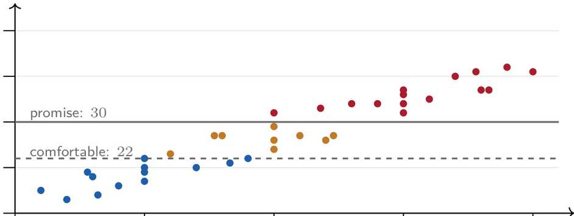

0

5

10

Distance (km)

15

20

Early (13, 22 min or less) ⋅ Just in time (9, 23–30) ⋅ Late (15, over 30). The outcome is now one of three labels, and 𝑌 is no longer 0 or 1.

## The multinomial model

Choose one category as the reference — say early. Then fit one linear predictor for each of the others:

log 𝑃(just 𝑃 (early) in time) = −6.9 + 0.9𝑋 log 𝑃 𝑃(late) (early) = −19.6 + 2.0𝑋

1

0.5

0

early late just in time

[figure not shown]

0

5

10

Distance (km)

15

20

Three curves now, one per category. The ticks along the top are the 37 observed outcomes.

## Three probabilities, one whole

1

0.5

0

10 km early just in time 10 km late

[figure not shown]

0

5

10

Distance (km)

15

20

At 10 km: 0.09 + 0.77 + 0.14 = 1.

0.14

0.77

0.09

km early

early just in t.

late total

4 0.96 6 0.82

0.96 0.04

0.04 0.00 1

0.82 0.18 8 0.42

0.18 0.00 1

10 0.09

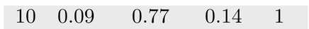

0.57 0.01 1 0.77 0.14 1

0.01 0.37 12 0.01

14 0.00

0.00 0.06

0.37 0.62 1 0.06 0.94 1

Each row is one vertical slice of the plot. A delivery has to be early, just in time or late, so the three probabilities always add up to 1.

## Interpreting the coefficients

Against the reference (early), each extra kilometre multiplies the odds

𝑃(just in time)/𝑃 (early) by 𝑒0.9 ≈ 2.5;

𝑃(late)/𝑃 (early) by 𝑒2.0 ≈ 7.4.

Late vs just in time: dividing the two ratios cancels 𝑃(early), so each extra kilometre multiplies 𝑃(late)/𝑃 (just in time) by

𝑒2.0 𝑒0.9 = 𝑒1.1 ≈ 3.0.

The two fitted equations:

log 𝑃(just 𝑃 (early) in time) = −6.9 + 0.9𝑋 log 𝑃 𝑃(late) (early) = −19.6 + 2.0𝑋

Subtract the first from the second; 𝑃(early) cancels:

log 𝑃 (just 𝑃(late) in time) = log 𝑃 𝑃(late) (early) − log 𝑃(just 𝑃 (early) in time)

= (−19.6 + 2.0𝑋) − (−6.9 + 0.9𝑋) = −12.7 + 1.1𝑋.

## Classifying into three

Predict the category with the largest probability. That splits the distances as:

under 7.7 km: early; 7.7 to 11.6 km: just in time; beyond 11.6 km: late.

1

0.5

0

early late 7.7 just in time 11.6

[figure not shown]

0

5

10

Distance (km)

15

Caveat: our three categories are ordered. Multinomial regression throws that away and would give the same answer if we shuffled the labels.

20

## Quick check: Part VII

With early as the reference category, our model reports a coefficient of 2.0 for late. What is it a statement about?

A The odds of being late, against all other outcomes combined

C The odds of being late rather than early, per extra kilometre

B The probability of being late rises by 2.0 per kilometre

D The number of late deliveries per kilometre

### Part VIII

# Limits and uncertainty

## Correlation ≠ Causation

The model says distant deliveries are more often late. Would shortening a route make it punctual? Not necessarily!

Recall:

## Extrapolation

Bounded [0, 1] ≠ safe extrapolation

Plausible-looking probabilities Data end at 20 km At 30 km: 𝑃(late) ≈ 1 The flat tail is a model assumption, not evidence

1

0.5

0

data here

0

10

no data — and a very confident curve

20

Distance (km)

30

40

## When the data separate

### Separation: coefficients → ∞

Heavy traffic + distance ⇒ near-perfect prediction

Almost no class overlap Steeper curve ⇒ better fit No finite likelihood maximum Small-sample problem, not a bug

1

0.5

0

0

5

10

Distance (km)

15

The 12 heavy-traffic deliveries: the fitting algorithm will never converge.

20

## The fitted curve is an estimate too

1

0.5

0

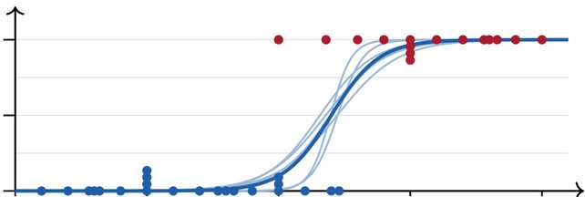

0

5

10

Distance (km)

15

20

Dark blue: curve with all 37 data points. Light blue: six refits using a subset of the data.

## Quick check: Part VIII

Software reports a coefficient of 37.4 with a standard error of 9 120, after warning that the fit did not converge. The most likely explanation is:

A Separation — that predictor splits late from on time almost perfectly

C The outcome was coded backwards

B The predictor is enormously important D The sample is too large

### Part IX

# Recap

## Linear and logistic, side by side

50

40

30

20

10

0

5

10

15

linear: how many minutes?

1

0.5

0

20

0

5

10

15

logistic: what chance of late?

|  | linear | logistic |  |
| --- | --- | --- | --- |
| outcome predicts | a number 𝑌, minutes | a label ?̂?, a probability |  |
| model 𝑏1 means | 𝑌 = 𝑏0 + 𝑏1𝑋 +1.5 min per km | log 1−𝑝 𝑝 = 𝑏0 odds × 3 per | + 𝑏1𝑋 km |
| fitted by | least squares | maximum | likelihood |
| fit measured baseline | MAE, 𝑅2 predict 𝑌 | likelihood, predict the | accuracy majority label |
| overfitting | a wiggly curve | over-confident | ?̂? |

20

The scaffolding is identical: a predictor, coefficients to interpret, a criterion to fit, a baseline to beat, and a held-out check.

Which single statement about our model log 1−𝑝 𝑝 = −13.2 + 1.1𝑋 is correct?

A A 16 km delivery is predicted to be late 17.6 minutes more often

C The model predicts that 110% of 20 km deliveries are late

B The odds of lateness roughly triple per kilometre, and the 50% point is 12 km

D 𝑏0 = −13.2 means deliveries of zero distance are 13.2 minutes early

## Quick check: the whole lecture

A delivery is 13 km long. Using log 1−𝑝 𝑝 = −13.2 + 1.1𝑋 and a threshold of 0.5, which statement is correct?

A 𝑝 = 1.1, which is above 1, so the model has broken down

C The log-odds are 1.1, so 𝑝 = 𝑒1.1/(1 + 𝑒1.1) ≈ 0.75 and it is flagged late

B The odds are 1.1, so 𝑝 = 1.1/2.1 ≈ 0.52 — only just flagged late

D The log-odds are positive, so the delivery is certain to be late

Our model classifies 33 of the 37 deliveries correctly (0.89). Which conclusion is justified?

A Distance causes lateness, so shortening routes will make deliveries punctual

C 89% is impressive whatever the data, so no further checks are needed

B It will be right about 89% of the time for 30 km deliveries too

D It beats the 0.59 always-on-time baseline, but only held-out deliveries show how it will do on new ones

## In this lecture we discussed…

Logistic regression predicts a probability for a yes/no outcome. A straight line cannot: it leaves [0, 1]. The logistic curve cannot leave it. The model is linear in the log-odds: log 1−𝑝 𝑝 = 𝑏0 + 𝑏1𝑋. 𝑒𝑏1 is an odds ratio; −𝑏0/𝑏1 is the 50% point. Coefficients are chosen by maximum likelihood, not least squares. A threshold turns a probability into a decision; the confusion matrix judges it. Accuracy needs a baseline, and generalisation needs held-out data. More than two categories: one equation per category against a reference, with the probabilities still adding to 1. Extrapolation, separation and sampling variability are the standing limits.

### Data → Fit → Predict → Decide → Evaluate